# 1. Load data, quality check, and integration

Cankun Wang

11/30/2022

# 1 Set working dir

```
## [1] "Current working directory: C:/Users/flyku/Documents/GitHub/BMBL-analysis-notebooks/scRNAseq_multi_sample_analysis"
```

# 2 Number of cells of the original data

```
##
## ctrl_raw_feature_bc_matrix stim_raw_feature_bc_matrix
##                      15325                      15277
```

# 3 QC metrics in the original data

Before analyzing the single-cell gene expression data, we must ensure that all cellular barcode data correspond to viable cells. Cell quality control is performed based on four QC covariates:

- The number of unique genes detected in each cell (nFeature_RNA). Low-quality cells or empty droplets will often have very few genes. Cell doublets or multiplets may exhibit an aberrantly high gene count.
- The total number of molecules detected within a cell (correlates strongly with unique genes) (nCount_RNA)
- The percentage of reads that map to the mitochondrial genome (percent.mito). Low-quality / dying cells often exhibit extensive mitochondrial contamination. We use the set of all genes starting with MT- as a set of mitochondrial genes
- The percentage of reads that map to the ribosomal genome (percent.ribo).

The violin plot for those four QC metrics was shown below:

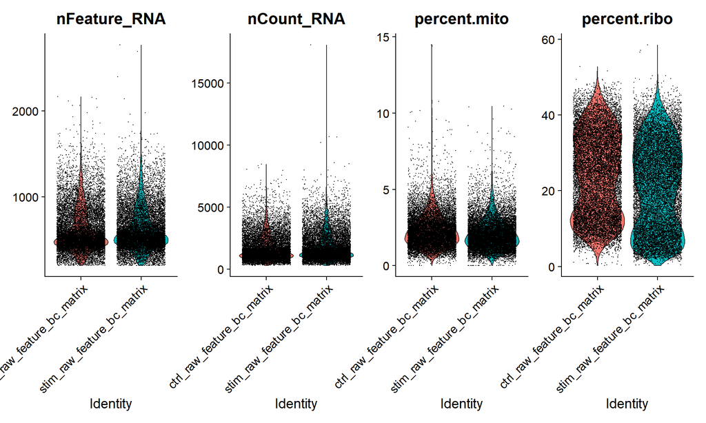

# 4 Filter cells and plot after QC

After checking the violin plots, these cells are removed:

- Cells with above 50% ribosomal reads
- Cells with above 5% mitochondrial reads
- Cells detected less than 200 genes and more than 1500 genes
- Cells with more than 6000 total reads

These genes were removed:

- Genes detected in fewer than 3 cells

| sample | before_qc | after_qc |
| --- | --- | --- |
| Total | 30602 | 29940 |
| ctrl_raw_feature_bc_matrix | 15325 | 14957 |
| stim_raw_feature_bc_matrix | 15277 | 14983 |

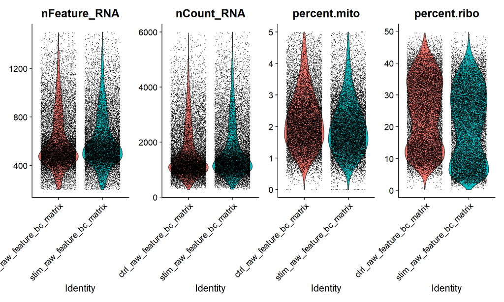

# 5 Integrate data

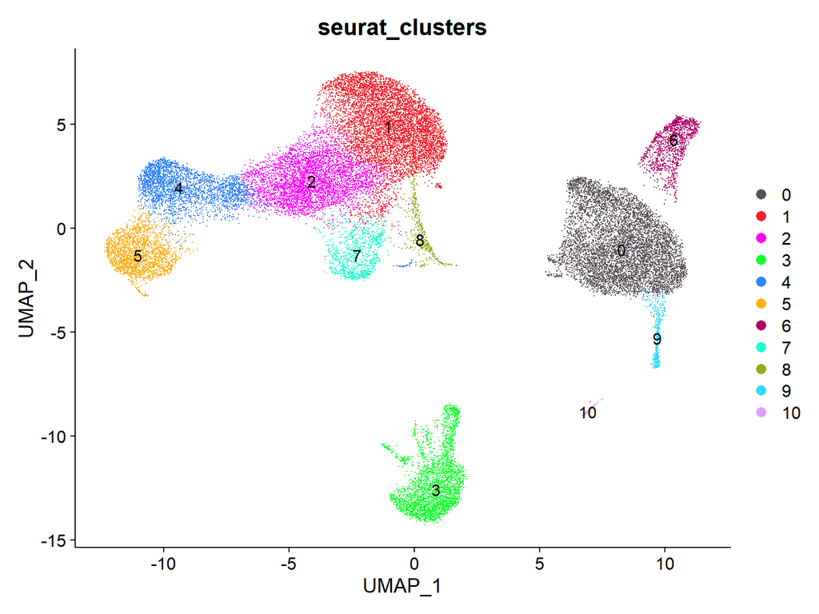

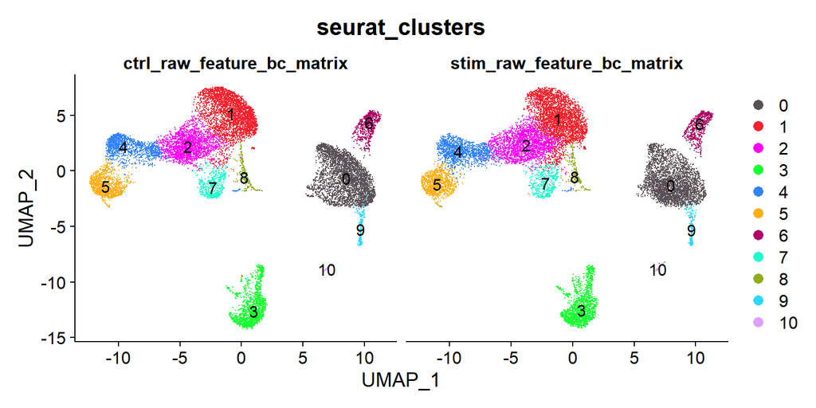